# R handout: Computer exercises lecture 9

Maarten Speekenbrink

5 December 2016

## Linear mixed-effects models in R

There are two widely used packages to estimate linear mixed-effects models in R: `nlme` and `lme4`. The `nlme` package is older and can estimate linear and non-linear mixed-effects models with Normally distributed errors. It allows you to specify various specialized covariance structures for the random-effects and also allows you to model correlations between the errors. The `lme4` package is newer (and developed by Douglas Bates, an authority on mixed-effects models who also co-developed the `nlme` package), simpler to use, allows you to specify mixed-effects models with non-Gaussian errors (e.g., mixed effects logistic regression models), is faster, and works better for models with many random effects. Here, we’ll use `lme4`.

The way you specify a mixed-effects model in `lme4` is very similar to the way you specify a general linear model. For models with Normally distributed errors, you make use of the `lmer` function (for Linear Mixed-Effects Regression). The (important) bits of the syntax are

`lmer(formula, data = NULL, REML = TRUE,...)`

where

- `formula` is a model formula, just like for the `lm` function, with an additional option to specify random effects. You can specify that you want to include a random part of an effect by enclosing a predictor (or `1` for the intercept) by parentheses. You also need to specify the unit of observation on which the random parts depends, by a “|” sign and then specifying the variable which contains the levels of the units of observation. So, for instance, if you have a model with dependent variable `y`, a single predictor called `week`, and there is a variable called `id` which contains the ID number of each participant, and you want to include a random intercept dependent on id, you could specify the formula as `y ~ 1 + week + (1|id)`. If you also want to include a random slope for `week`, you could specify the formula as `y ~ 1 + week + (1 + week|id)`. By enclosing multiple effects within the same parentheses, you are allowing these effects to be correlated. If you want the random effects to be independent, you should specify them in separate parentheses, so `y ~ 1 + week + (1|id) + (0 + week|id)`. Note that it is necessary to put the `0` with week in this case to explicitly state that this bit should not include an intercept (just like `lm`, `lmer` assumes intercepts by default).
- `data` should be a data frame in the “long” format (e.g., unlike for repeated-measures, you should have multiple rows for each participant, one row for each repeated-measure)
- `REML` is a logical argument specifying whether to use Restricted Maximum Likelihood (`REML = TRUE`) or Maximum Likelihood (`REML = FALSE`)

For example, let’s use the `Reisby.sav` data discussed in the lecture. Let’s estimate a mixed-effects model with level 1 structure:
$$\text{HamD}_{hi} = \beta_{0i} + \beta_{1i} \text{week}_{hi} + \epsilon_{hi}$$
and level 2 structure
$$\begin{align*} \beta_{0i} &= \beta_0 + \alpha_{0i} \\ \beta_{1i} &= \beta_1 + \alpha_{1i} \end{align*}$$
i.e. a model with both random intercepts and random slopes, and let’s allow a correlation between the random effects.

```r
# load the data
library(foreign)
dat <- as.data.frame(read.spss("Reisby.sav"))
head(dat)
```

```
##    Id HamD Week WeekSq Endogenous EndoWeek EndoWeekSq
## 1 101   26    0      0         -1        0          0
## 2 101   22    1      1         -1       -1         -1
## 3 101   18    2      4         -1       -2         -4
## 4 101    7    3      9         -1       -3         -9
## 5 101    4    4     16         -1       -4        -16
## 6 101    3    5     25         -1       -5        -25
```

```r
# load the lme4 package
library(lme4)
## estimate a mixed-effects model with REML (default)
mod <- lmer(HamD ~ 1 + Week + (1 + Week|Id),data=dat)
# summarize the results
summary(mod)
```

```
## Linear mixed model fit by REML ['lmerMod']
## Formula: HamD ~ 1 + Week + (1 + Week | Id)
##    Data: dat
##
## REML criterion at convergence: 2219.9
##
## Scaled residuals:
##     Min      1Q  Median      3Q     Max
## -2.7358 -0.4982  0.0332  0.5145  3.6793
##
## Random effects:
##  Groups   Name        Variance Std.Dev. Corr
##  Id       (Intercept) 12.944   3.598
##           Week         2.126   1.458    -0.28
##  Residual             12.213   3.495
## Number of obs: 375, groups:  Id, 66
##
## Fixed effects:
##             Estimate Std. Error t value
## (Intercept)  23.5770     0.5499   42.88
## Week         -2.3770     0.2103  -11.30
##
## Correlation of Fixed Effects:
##      (Intr)
## Week -0.450
```

Note that the output provides you with the parameter estimates, but no $p$-values. This is because the author (for good reasons, actually) doesn’t believe in the method of correcting the degrees of freedom of the test statistics to obtain valid test results. Also note that SPSS provides further additional output, such as Wald tests for the random effects variances, and overall model results such as the “-2 log likelihood”.

### Multilevel models

To specify a multilevel model, you can indicate the hierarchical structure in the random effects part of the formula, by separating levels in the hierarchy by a “/” sign. For instance, if you want to estimate a model in which you want a random intercept for classrooms, and students within classrooms, you can specify the random effects part as

`(1 | classrooms/students)`

which you can read as “students nested within classrooms”. If you want to estimate a model in which you want a random intercept for schools, classrooms within schools, and students within classrooms, you can specify the random effects part as

`(1 | schools/classrooms/students)`

### Obtaining the -2 log likelihood and likelihood ratio tests

To get the “-2 log likelihood” value, you can use the `logLik` function:

```r
# the log likelihood
logLik(mod)
```

```
## 'log Lik.' -1109.959 (df=6)
```

```r
# multiply this by -2 to get the -2 log likelihood:
-2 * logLik(mod)
```

```
## 'log Lik.' 2219.918 (df=6)
```

```r
# get the AIC
AIC(mod)
```

```
## [1] 2231.918
```

Note that these are computed for a model which was estimated by REML, so these are technically “log restricted likelihood” values. You should really re-estimate the model with ML to get the correct log likelihood values:

```r
modML <- lmer(HamD ~ 1 + Week + (1 + Week|Id),data=dat,REML=FALSE)
## you can also do this with the refitML function:
modML <- refitML(mod)
logLik(modML)
```

```
## 'log Lik.' -1109.519 (df=6)
```

```r
-2 * logLik(modML)
```

```
## 'log Lik.' 2219.038 (df=6)
```

To get a likelihood-ratio test, you can use the `anova` function. Let’s test whether the covariance between intercept and slope is significant by estimating a model where we assume the random effects are independent, and then comparing this to the model we estimated above:

```r
modMLindep <- lmer(HamD ~ 1 + Week + (1|Id) + (0 + Week|Id),data=dat,REML=FALSE)
anova(modMLindep,modML)
```

```
## Data: dat
## Models:
## modMLindep: HamD ~ 1 + Week + (1 | Id) + (0 + Week | Id)
## modML: HamD ~ 1 + Week + (1 + Week | Id)
##            Df    AIC    BIC  logLik deviance  Chisq Chi Df Pr(>Chisq)
## modMLindep  5 2231.4 2251.0 -1110.7   2221.4
## modML       6 2231.0 2254.6 -1109.5   2219.0 2.3364      1     0.1264
```

### Obtaining confidence intervals for the random-effects covariances

Unfortunately, there is no easy way to get Wald tests for the random-effects covariances to replicate the SPSS output. But perhaps that is really a blessing, as the Wald test is pretty rubbish anyway (as explained in the lecture). The `lme4` package does allow you a better way to infer whether a (co-)variance is significantly different from 0 by computing confidence intervals around the parameters. These can be obtained via the `confint` function, which provides a confidence interval for each parameter in the model.

```r
confint(mod)
```

```
## Computing profile confidence intervals ...
```

```
##                  2.5 %      97.5 %
## .sig01       2.6370456  4.62552904
## .sig02      -0.5493499  0.08827253
## .sig03       1.1191403  1.83470431
## .sigma       3.2035517  3.83414862
## (Intercept) 22.4915808 24.66269398
## Week        -2.7924190 -1.96194440
```

### Plotting model predictions

To get plots of the model predictions for each unit of observation (e.g., participants), we can first save the model predictions in the `data.frame`, using the `predict` function called on a model fitted by `lmer`. Note that this function only gives predictions for those cases where the dependent variable is not missing (as missing values are excluded when estimating the models).

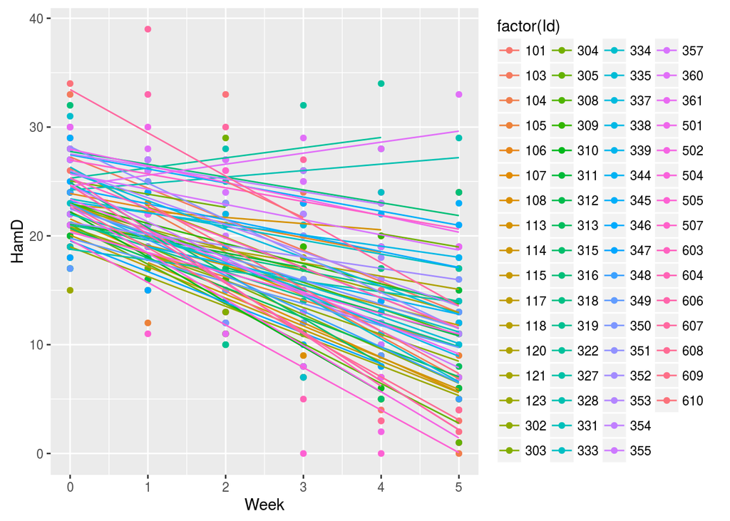

```r
# save the model predictions in a variable called "pred"
# only assign predictions to those rows where HamD is *not* missing:
dat$pred[!is.na(dat$HamD)] <- predict(mod)
## load the ggplot2 package for pretty plots
library(ggplot2)
# create a plot' the ggplot2 package is not easy to use
# but you can use this template to create similar plots
# just replace the y, x, group, colour arguments for
# other data frames (as well as the 'pred' name if you
# call this something else)
# the geom_point draws the dots of the observed data
# the geom_line draws the lines for the model predictions
ggplot(dat,aes(y=HamD,x=Week,group=factor(Id),colour=factor(Id))) + geom_point() + geom_line(aes(y=pred,x=Week,group=factor(Id),colour=factor(Id)))
```

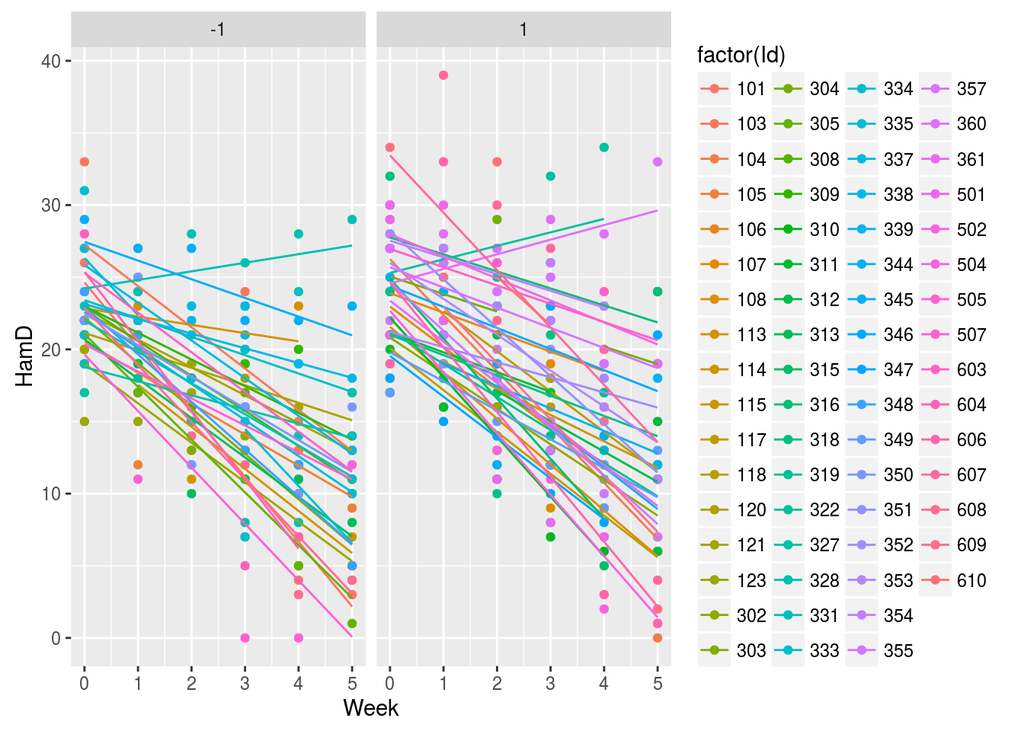

```r
## you can also make separate plots for each level of endogeneous
ggplot(dat,aes(y=HamD,x=Week,group=factor(Id),colour=factor(Id))) + geom_point() + geom_line(aes(y=pred,x=Week,group=factor(Id),colour=factor(Id))) + facet_wrap(~Endogenous)
```

## Obtaining p-values with the lmerTest package

To get $p$-values for the fixed-effects, just like SPSS provides, you can use the `lmerTest` package, which corrects the degrees of freedom with the Satterthwaite correction. When you load the `lmerTest` package, it defines an extended `lmer` function which allows you to compute the $p$-values. After loading the `lmerTest` package, when you call the `summary` function on an estimated model, the output will show the $p$-values:

```r
library(lmerTest)
mod <- lmer(HamD ~ 1 + Week + (1 + Week|Id),data=dat)
summary(mod)
```

```
## Linear mixed model fit by REML t-tests use Satterthwaite approximations
##   to degrees of freedom [lmerMod]
## Formula: HamD ~ 1 + Week + (1 + Week | Id)
##    Data: dat
##
## REML criterion at convergence: 2219.9
##
## Scaled residuals:
##     Min      1Q  Median      3Q     Max
## -2.7358 -0.4982  0.0332  0.5145  3.6793
##
## Random effects:
##  Groups   Name        Variance Std.Dev. Corr
##  Id       (Intercept) 12.944   3.598
##           Week         2.126   1.458    -0.28
##  Residual             12.213   3.495
## Number of obs: 375, groups:  Id, 66
##
## Fixed effects:
##             Estimate Std. Error      df t value Pr(>|t|)
## (Intercept)  23.5770     0.5499 62.8200   42.88   <2e-16 ***
## Week         -2.3770     0.2103 62.1800  -11.30   <2e-16 ***
## ---
## Signif. codes:  0 '***' 0.001 '**' 0.01 '*' 0.05 '.' 0.1 ' ' 1
##
## Correlation of Fixed Effects:
##      (Intr)
## Week -0.450
```

If you want the omnibus tests for factors, you can use the `anova` function on the model:

```r
anova(mod)
```

```
## Analysis of Variance Table of type III  with  Satterthwaite
## approximation for degrees of freedom
##      Sum Sq Mean Sq NumDF  DenDF F.value    Pr(>F)
## Week 1559.6  1559.6     1 62.182   127.7 < 2.2e-16 ***
## ---
## Signif. codes:  0 '***' 0.001 '**' 0.01 '*' 0.05 '.' 0.1 ' ' 1
```